# Executive Report

## Customer Setgmentation Analysis

```python
import pandas as pd
import numpy as np
from matplotlib import pyplot as plt
import seaborn as sns
from sklearn.cluster import KMeans
from sklearn.preprocessing import LabelEncoder
from sklearn.preprocessing import StandardScaler
from sklearn.decomposition import PCA
from sklearn.cluster import DBSCAN
```

```python
data = pd.read_csv('./Customer_seg/customer_segmentation_data.csv')
data.head()
```

|  | id | age | gender | income | spending_score | membership_years | purchase_frequency | preferred_category | last_purchase_amount |
| --- | --- | --- | --- | --- | --- | --- | --- | --- | --- |
| 0 | 1 | 38 | Female | 99342 | 90 | 3 | 24 | Groceries | 113.53 |
| 1 | 2 | 21 | Female | 78852 | 60 | 2 | 42 | Sports | 41.93 |
| 2 | 3 | 60 | Female | 126573 | 30 | 2 | 28 | Clothing | 424.36 |
| 3 | 4 | 40 | Other | 47099 | 74 | 9 | 5 | Home & Garden | 991.93 |
| 4 | 5 | 65 | Female | 140621 | 21 | 3 | 25 | Electronics | 347.08 |

```python
data.shape
```

```
(1000, 9)
```

```python
data.isnull().sum()
```

```
id                      0
age                     0
gender                  0
income                  0
spending_score          0
membership_years        0
purchase_frequency      0
preferred_category      0
last_purchase_amount    0
dtype: int64
```

```python
data.describe()
```

|  | id | age | income | spending_score | membership_years | purchase_frequency | last_purchase_amount |
| --- | --- | --- | --- | --- | --- | --- | --- |
| count | 1000.000000 | 1000.000000 | 1000.000000 | 1000.000000 | 1000.00000 | 1000.000000 | 1000.000000 |
| mean | 500.500000 | 43.783000 | 88500.800000 | 50.685000 | 5.46900 | 26.596000 | 492.348670 |
| std | 288.819436 | 15.042213 | 34230.771122 | 28.955175 | 2.85573 | 14.243654 | 295.744253 |
| min | 1.000000 | 18.000000 | 30004.000000 | 1.000000 | 1.00000 | 1.000000 | 10.400000 |
| 25% | 250.750000 | 30.000000 | 57911.750000 | 26.000000 | 3.00000 | 15.000000 | 218.762500 |
| 50% | 500.500000 | 45.000000 | 87845.500000 | 50.000000 | 5.00000 | 27.000000 | 491.595000 |
| 75% | 750.250000 | 57.000000 | 116110.250000 | 76.000000 | 8.00000 | 39.000000 | 747.170000 |
| max | 1000.000000 | 69.000000 | 149973.000000 | 100.000000 | 10.00000 | 50.000000 | 999.740000 |

```python
data.info()
```

```
<class 'pandas.core.frame.DataFrame'>
RangeIndex: 1000 entries, 0 to 999
Data columns (total 9 columns):
 #   Column                Non-Null Count  Dtype
---  ------                --------------  -----
 0   id                    1000 non-null   int64
 1   age                   1000 non-null   int64
 2   gender                1000 non-null   object
 3   income                1000 non-null   int64
 4   spending_score        1000 non-null   int64
 5   membership_years      1000 non-null   int64
 6   purchase_frequency    1000 non-null   int64
 7   preferred_category    1000 non-null   object
 8   last_purchase_amount  1000 non-null   float64
dtypes: float64(1), int64(6), object(2)
memory usage: 70.4+ KB
```

```python
le = LabelEncoder()
gender_label = le.fit_transform(data['gender'])
gender_label_maping = dict(zip(le.classes_, le.transform(le.classes_)))
gender_label_maping
```

```
{'Female': np.int64(0), 'Male': np.int64(1), 'Other': np.int64(2)}
```

```python
pref_cat_label = le.fit_transform(data['preferred_category'])
pref_cat_label_maping = dict(zip(le.classes_, le.transform(le.classes_)))
pref_cat_label_maping
```

```
{'Clothing': np.int64(0),
 'Electronics': np.int64(1),
 'Groceries': np.int64(2),
 'Home & Garden': np.int64(3),
 'Sports': np.int64(4)}
```

```python
data_mod = data.drop(['id', 'gender','preferred_category'], axis=1)
data_mod['gender'] = gender_label
data_mod['preferred_category'] = pref_cat_label
```

```python
data_mod.describe()
```

|  | age | income | spending_score | membership_years | purchase_frequency | last_purchase_amount | gender | preferred_category |
| --- | --- | --- | --- | --- | --- | --- | --- | --- |
| count | 1000.000000 | 1000.000000 | 1000.000000 | 1000.00000 | 1000.000000 | 1000.000000 | 1000.000000 | 1000.000000 |
| mean | 43.783000 | 88500.800000 | 50.685000 | 5.46900 | 26.596000 | 492.348670 | 1.011000 | 2.071000 |
| std | 15.042213 | 34230.771122 | 28.955175 | 2.85573 | 14.243654 | 295.744253 | 0.802199 | 1.392084 |
| min | 18.000000 | 30004.000000 | 1.000000 | 1.00000 | 1.000000 | 10.400000 | 0.000000 | 0.000000 |
| 25% | 30.000000 | 57911.750000 | 26.000000 | 3.00000 | 15.000000 | 218.762500 | 0.000000 | 1.000000 |
| 50% | 45.000000 | 87845.500000 | 50.000000 | 5.00000 | 27.000000 | 491.595000 | 1.000000 | 2.000000 |
| 75% | 57.000000 | 116110.250000 | 76.000000 | 8.00000 | 39.000000 | 747.170000 | 2.000000 | 3.000000 |
| max | 69.000000 | 149973.000000 | 100.000000 | 10.00000 | 50.000000 | 999.740000 | 2.000000 | 4.000000 |

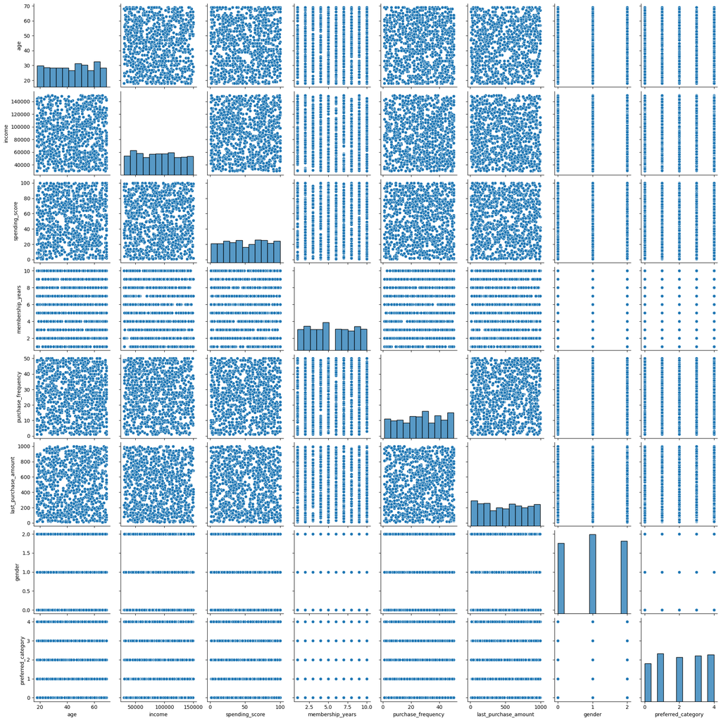

```python
sns.pairplot(data_mod)
```

```python
SS = StandardScaler()
X = SS.fit(data_mod).transform(data_mod)
```

```python
pca2 = PCA(n_components=2)
X_PCA = pca2.fit(X).transform(X)
```

```python
X_PCA
```

```
array([[-1.88695207,  0.0291139 ],
       [-2.23483501,  0.82026241],
       [-0.95666988, -1.25667335],
       ...,
       [-1.52722355,  1.07236745],
       [-1.06486346,  1.65121928],
       [-0.78154912, -0.79105567]], shape=(1000, 2))
```

```python
loadings_PCA = pd.DataFrame(
    pca2.components_.T,
    columns=['PCA1', 'PCA2'],
    index=data_mod.columns
)

print(loadings_PCA.sort_values(by='PCA1', ascending=False)['PCA1'])
```

```
last_purchase_amount    0.632869
gender                  0.541963
age                     0.388245
membership_years        0.207986
purchase_frequency      0.175795
spending_score          0.041662
preferred_category     -0.020734
income                 -0.280520
Name: PCA1, dtype: float64
```

### Interpretación de PCA1

🔹 Principales contribuyentes (coeficientes más altos en valor absoluto):

- last_purchase_amount (0.633) → mayor peso
- gender (0.542)
- age (0.388)

#### Entonces PCA1 mide principalmente:

Una combinación de comportamiento de compra y demografía, especialmente personas con alto monto de última compra, cierto género (codificado, por ejemplo 0/1), y mayor edad.

También hay influencia moderada de:

- membership_years y purchase_frequency (positivo)
- income (negativo, pero menor en magnitud)

Un valor alto en PCA1 → cliente con:

- Alta edad
- Alta última compra
- Probablemente de un género específico (según codificación)
- Más antigüedad como cliente

```python
print(loadings_PCA.sort_values(by='PCA2', ascending=False)['PCA2'])
```

```
membership_years        0.647124
purchase_frequency      0.594039
spending_score          0.212101
preferred_category     -0.028038
gender                 -0.057221
income                 -0.141926
last_purchase_amount   -0.191902
age                    -0.349759
Name: PCA2, dtype: float64
```

### Interpretación de PCA2

🔹 Principales contribuyentes:

- membership_years (0.647)
- purchase_frequency (0.594)
- spending_score (0.212)

#### Entonces PCA2 mide principalmente:

- Un componente de fidelidad o engagement, relacionado con el tiempo de membresía y frecuencia de compra.

Un valor alto en PCA2 → cliente activo y antiguo, con frecuente interacción o compras.

### interpretar los clusters del GMM

- Si un cluster está en la parte alta de PCA1 y baja de PCA2, probablemente son clientes de alto poder adquisitivo o grandes compradores, pero no tan leales.
- Un cluster con alto PCA2 y bajo PCA1 puede ser de clientes fieles con menor nivel de gasto individual.
- Un cluster alto en ambos → clientes muy valiosos (grandes compras y alta frecuencia / antigüedad).
- Clusters bajos en ambos → clientes nuevos o poco comprometidos.

## K-Means

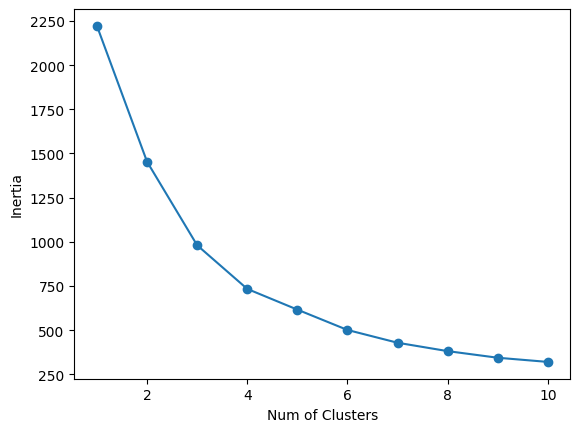

```python
inertia = []
list_num_clusters = list(range(1,11))
for num_clusters in list_num_clusters:
    km = KMeans(n_clusters=num_clusters, random_state=42)
    km.fit(X_PCA)
    inertia.append(km.inertia_)
plt.plot(list_num_clusters, inertia)
plt.scatter(list_num_clusters, inertia)
plt.xlabel('Num of Clusters')
plt.ylabel('Inertia')
```

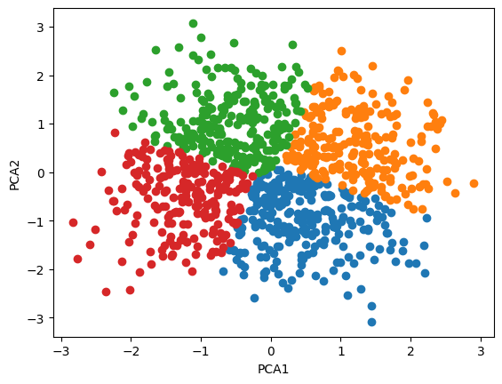

```python
km = KMeans(n_clusters=4, random_state=42)
km.fit(X_PCA)
labels = km.labels_
for label in np.unique(km.labels_):
    X_ = X_PCA[label == km.labels_]
    plt.scatter(X_[:,0], X_[:,1], label=label)

plt.xlabel('PCA1')
plt.ylabel('PCA2')
plt.show()
```

## Gaussian Mixture

```python
from sklearn.mixture import GaussianMixture
model = GaussianMixture(n_components=4, random_state=0)
model.fit(X_PCA)
```

```
GaussianMixture(n_components=4, random_state=0)
```

```python
X_pred = model.predict(X_PCA)
```

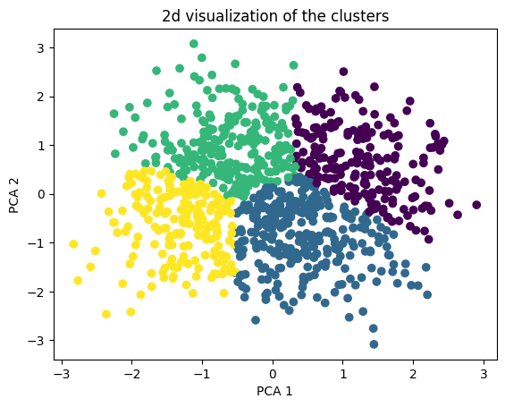

```python
x = X_PCA[:,0]
y = X_PCA[:,1]
plt.scatter(x, y, c=X_pred)
plt.title("2d visualization of the clusters")
plt.xlabel("PCA 1")
plt.ylabel("PCA 2")
```

## Mean Shift Clustering

```python
from sklearn.cluster import MeanShift, estimate_bandwidth
```

```python
bandwidth = estimate_bandwidth(X_PCA, quantile=.07, n_samples=1000)
bandwidth
```

```
np.float64(0.658670257728277)
```

```python
ms = MeanShift(bandwidth=bandwidth,bin_seeding=True)
ms.fit(X_PCA)
labeled=ms.labels_
clusters=ms.predict(X_PCA)
```

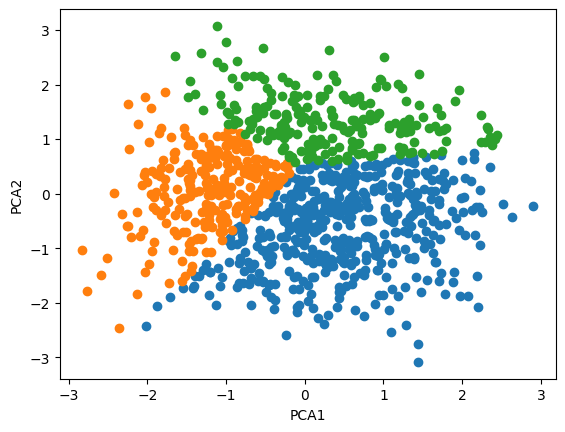

```python
labels = km.labels_
for label in np.unique(ms.labels_):
    X_ = X_PCA[label == ms.labels_]
    plt.scatter(X_[:,0], X_[:,1], label=label)

plt.xlabel('PCA1')
plt.ylabel('PCA2')
plt.show()
```